# Spatially explicit models for distance sampling data

Practical “solution” 4: Model checking

David L Miller

## Aims

By the end of this practical, you should feel comfortable:

- Looking at how changing `k` changes smooths
- Plotting residuals vs. covariates
- Fitting models to the residuals
- Using `gam.check` and `rqgam.check`
- Using `obs_exp`

## Load data and packages

```r
library(Distance)
library(dsm)
```

```r
library(ggplot2)
library(knitr)
```

Load the data and the fitted `dsm` objects from the previous exercises:

```r
load("spermwhale.RData")
load("dsms.RData")
load("df-models.RData")
```

We’re going to check the DSMs that we fitted in the previous practical, then save those that we think are good!

**Pre-model fitting**

As we did in the previous exercise, we must remove the observations from the spatial data that we excluded when we fitted the detection function, i.e. those observations at distances greater than the truncation.

```r
obs <- obs[obs$distance <= df_hn$ddf$meta.data$width, ]
```

## Looking at how changing `k` changes smooths

First checking that `k` is big enough, we should really do this during model fitting, but we’ve separated this up for the practical exercises.

First look at the text output of `gam.check`, are the values of `k'` for your models close to the `edf` in the outputted table. Here’s a silly example where I’ve deliberately set `k` too small:

```r
dsm_k_check_eg <- dsm(count ~ s(Depth, k=4),
                    df_hn, segs, obs,
                    family=tw())
gam.check(dsm_k_check_eg)
```

```
##
## Method: REML   Optimizer: outer newton
## full convergence after 8 iterations.
## Gradient range [-1.66079e-07,1.171305e-07]
## (score 392.2823 & scale 5.216272).
## Hessian positive definite, eigenvalue range [0.8702242,302.9225].
## Model rank =  4 / 4
##
## Basis dimension (k) checking results. Low p-value (k-index<1) may
## indicate that k is too low, especially if edf is close to k'.
##
##           k' edf k-index p-value
## s(Depth) 3.0 2.9    0.78    0.17
```

Generally if the EDF is close to the value of `k` you supplied, it is worth doubling `k` and refitting to see what happens. You can always switch back to the smaller `k` if there is little difference. The `?choose.k` manual page can offer some guidance.

Continuing with that example, if we double `k`:

```r
dsm_k_check_eg <- dsm(count ~ s(Depth, k=8),
                    df_hn, segs, obs,
                    family=tw())
gam.check(dsm_k_check_eg)
```

```
##
## Method: REML   Optimizer: outer newton
## full convergence after 8 iterations.
## Gradient range [-5.675949e-08,4.752562e-08]
## (score 392.2128 & scale 5.216315).
## Hessian positive definite, eigenvalue range [1.313321,300.6316].
## Model rank =  8 / 8
##
## Basis dimension (k) checking results. Low p-value (k-index<1) may
## indicate that k is too low, especially if edf is close to k'.
##
##            k'  edf k-index p-value
## s(Depth) 7.00 4.47    0.78    0.26
```

We get something much more reasonable. Doubling again

```r
dsm_k_check_eg <- dsm(count ~ s(Depth, k=16),
                    df_hn, segs, obs,
                    family=tw())
gam.check(dsm_k_check_eg)
```

```
##
## Method: REML   Optimizer: outer newton
## full convergence after 7 iterations.
## Gradient range [-4.245788e-07,3.205948e-07]
## (score 392.2614 & scale 5.213115).
## Hessian positive definite, eigenvalue range [1.440887,300.5744].
## Model rank =  16 / 16
##
## Basis dimension (k) checking results. Low p-value (k-index<1) may
## indicate that k is too low, especially if edf is close to k'.
##
##             k'   edf k-index p-value
## s(Depth) 15.00  4.83    0.78    0.17
```

We see almost no improvement, so might refit the second model here with `k=8`.

Check to see if any of your models need this treatment.

**Checking `k` size**

I saved the following models last time: `dsm_nb_xy_ms_p1_4`, `dsm_tw_xy_ms`, `dsm_nb_noxy_ms_p1_3`, `dsm_nb_xy`, `dsm_tw_xy`, `dsm_nb_xy_ms_ae` and `dsm_tw_xy_ms_ae`.

I’ll run `gam.check` on each. Note that I’ve used the `fig.show='hide'` “chunk” option in RMarkdown to suppress the plots here and save space

```r
gam.check(dsm_nb_xy_ms_p1_4)
```

```
##
## Method: REML   Optimizer: outer newton
## full convergence after 6 iterations.
## Gradient range [-1.246014e-07,3.24631e-05]
## (score 382.759 & scale 1).
## Hessian positive definite, eigenvalue range [0.3417744,30.6163].
## Model rank =  48 / 48
##
## Basis dimension (k) checking results. Low p-value (k-index<1) may
## indicate that k is too low, especially if edf is close to k'.
##
##              k'    edf k-index p-value
## s(x,y)   29.000  1.864    0.55  <2e-16 ***
## s(Depth)  9.000  3.418    0.69   0.045 *
## s(EKE)    9.000  0.856    0.74   0.680
## ---
## Signif. codes:  0 '***' 0.001 '**' 0.01 '*' 0.05 '.' 0.1 ' ' 1
```

```r
gam.check(dsm_tw_xy_ms)
```

```
##
## Method: REML   Optimizer: outer newton
## full convergence after 11 iterations.
## Gradient range [-7.566865e-07,4.88331e-07]
## (score 385.0946 & scale 4.573293).
## Hessian positive definite, eigenvalue range [0.3357644,301.6658].
## Model rank =  48 / 48
##
## Basis dimension (k) checking results. Low p-value (k-index<1) may
## indicate that k is too low, especially if edf is close to k'.
##
##              k'    edf k-index p-value
## s(x,y)   29.000  1.897    0.62  <2e-16 ***
## s(Depth)  9.000  3.695    0.81    0.48
## s(EKE)    9.000  0.811    0.82    0.52
## ---
## Signif. codes:  0 '***' 0.001 '**' 0.01 '*' 0.05 '.' 0.1 ' ' 1
```

```r
gam.check(dsm_nb_noxy_ms_p1_3)
```

```
##
## Method: REML   Optimizer: outer newton
## full convergence after 6 iterations.
## Gradient range [-2.657814e-08,5.557278e-06]
## (score 383.0449 & scale 1).
## Hessian positive definite, eigenvalue range [0.3565081,30.73282].
## Model rank =  28 / 28
##
## Basis dimension (k) checking results. Low p-value (k-index<1) may
## indicate that k is too low, especially if edf is close to k'.
##
##             k'   edf k-index p-value
## s(Depth) 9.000 3.415    0.69   0.025 *
## s(EKE)   9.000 0.866    0.74   0.700
## s(NPP)   9.000 2.814    0.68   0.025 *
## ---
## Signif. codes:  0 '***' 0.001 '**' 0.01 '*' 0.05 '.' 0.1 ' ' 1
```

```r
gam.check(dsm_nb_xy)
```

```
##
## Method: REML   Optimizer: outer newton
## full convergence after 4 iterations.
## Gradient range [2.05065e-09,4.38541e-08]
## (score 394.963 & scale 1).
## Hessian positive definite, eigenvalue range [2.166966,29.85537].
## Model rank =  25 / 25
##
## Basis dimension (k) checking results. Low p-value (k-index<1) may
## indicate that k is too low, especially if edf is close to k'.
##
##          k'  edf k-index p-value
## s(x,y) 24.0 13.9    0.51  <2e-16 ***
## ---
## Signif. codes:  0 '***' 0.001 '**' 0.01 '*' 0.05 '.' 0.1 ' ' 1
```

```r
gam.check(dsm_tw_xy)
```

```
##
## Method: REML   Optimizer: outer newton
## full convergence after 7 iterations.
## Gradient range [-3.976573e-07,8.201047e-08]
## (score 396.9528 & scale 4.966045).
## Hessian positive definite, eigenvalue range [2.604446,301.2817].
## Model rank =  25 / 25
##
## Basis dimension (k) checking results. Low p-value (k-index<1) may
## indicate that k is too low, especially if edf is close to k'.
##
##          k'  edf k-index p-value
## s(x,y) 24.0 14.5     0.6  <2e-16 ***
## ---
## Signif. codes:  0 '***' 0.001 '**' 0.01 '*' 0.05 '.' 0.1 ' ' 1
```

```r
gam.check(dsm_nb_xy_ms_ae)
```

```
##
## Method: REML   Optimizer: outer newton
## full convergence after 7 iterations.
## Gradient range [1.666612e-10,2.633464e-09]
## (score 505.0342 & scale 1).
## Hessian positive definite, eigenvalue range [0.2941817,44.37103].
## Model rank =  48 / 48
##
## Basis dimension (k) checking results. Low p-value (k-index<1) may
## indicate that k is too low, especially if edf is close to k'.
##
##              k'    edf k-index p-value
## s(x,y)   29.000  1.335    0.46  <2e-16 ***
## s(Depth)  9.000  3.503    0.55   0.025 *
## s(EKE)    9.000  0.772    0.60   0.795
## ---
## Signif. codes:  0 '***' 0.001 '**' 0.01 '*' 0.05 '.' 0.1 ' ' 1
```

```r
gam.check(dsm_tw_xy_ms_ae)
```

```
##
## Method: REML   Optimizer: outer newton
## full convergence after 11 iterations.
## Gradient range [-2.828872e-06,1.348677e-06]
## (score 455.5013 & scale 8.662789).
## Hessian positive definite, eigenvalue range [0.3430708,293.2559].
## Model rank =  48 / 48
##
## Basis dimension (k) checking results. Low p-value (k-index<1) may
## indicate that k is too low, especially if edf is close to k'.
##
##              k'    edf k-index p-value
## s(x,y)   29.000  1.900    0.66  <2e-16 ***
## s(Depth)  9.000  3.772    0.84    0.59
## s(EKE)    9.000  0.826    0.84    0.60
## ---
## Signif. codes:  0 '***' 0.001 '**' 0.01 '*' 0.05 '.' 0.1 ' ' 1
```

(That might have taken a while to run!)

Sifting through these results, most of the cases were the $p$-value is significant (at any level beyond 0.1) it’s the case that the EDF is far from $k^\prime$. The only models I am worried about are `dsm_nb_xy` and `dsm_tw_xy` where the $p$-value is singificant *and* $k^\prime$ is “near” the EDF (it’s not that near but is is over half, so let’s check it out).

For the Tweedie model we set `k=25` and got an EDF of 14.5, so we’ll double `k` to 50:

```r
dsm_tw_xy <- dsm(count~s(x,y, bs="ts", k=50),
                    df_hn, segs, obs,
                    family=tw())
summary(dsm_tw_xy)
```

```
##
## Family: Tweedie(p=1.283)
## Link function: log
##
## Formula:
## count ~ s(x, y, bs = "ts", k = 50) + offset(off.set)
##
## Parametric coefficients:
##             Estimate Std. Error t value Pr(>|t|)
## (Intercept) -20.6281     0.2518  -81.92   <2e-16 ***
## ---
## Signif. codes:  0 '***' 0.001 '**' 0.01 '*' 0.05 '.' 0.1 ' ' 1
##
## Approximate significance of smooth terms:
##          edf Ref.df     F p-value
## s(x,y) 20.34     49 2.068  <2e-16 ***
## ---
## Signif. codes:  0 '***' 0.001 '**' 0.01 '*' 0.05 '.' 0.1 ' ' 1
##
## R-sq.(adj) =  0.125   Deviance explained = 37.5%
## -REML = 406.92  Scale est. = 4.6374    n = 949
```

```r
gam.check(dsm_tw_xy)
```

```
##
## Method: REML   Optimizer: outer newton
## full convergence after 6 iterations.
## Gradient range [-0.0001153251,2.507349e-05]
## (score 406.9169 & scale 4.637444).
## Hessian positive definite, eigenvalue range [1.816522,297.6612].
## Model rank =  50 / 50
##
## Basis dimension (k) checking results. Low p-value (k-index<1) may
## indicate that k is too low, especially if edf is close to k'.
##
##          k'  edf k-index p-value
## s(x,y) 49.0 20.3    0.62  <2e-16 ***
## ---
## Signif. codes:  0 '***' 0.001 '**' 0.01 '*' 0.05 '.' 0.1 ' ' 1
```

Okay that’s a moderate jump there! We can see now the EDF is less than half of $k^\prime$ **but** as we can see the $p$-value is still significant. It’s not likely that increasing $k$ will do anything here. As I said in the lecture, we need to look at $k^\prime$, the EDF and the $p$-value here to see what’s going on.

We can do the same thing with the negative binomial model, there the EDF was 13.9 when `k=25`.

```r
dsm_nb_xy <- dsm(count~s(x,y, bs="ts", k=50),
                    df_hn, segs, obs,
                    family=nb())
summary(dsm_nb_xy)
```

```
##
## Family: Negative Binomial(0.108)
## Link function: log
##
## Formula:
## count ~ s(x, y, bs = "ts", k = 50) + offset(off.set)
##
## Parametric coefficients:
##             Estimate Std. Error z value Pr(>|z|)
## (Intercept) -20.6787     0.2423  -85.35   <2e-16 ***
## ---
## Signif. codes:  0 '***' 0.001 '**' 0.01 '*' 0.05 '.' 0.1 ' ' 1
##
## Approximate significance of smooth terms:
##          edf Ref.df Chi.sq p-value
## s(x,y) 19.75     49  81.49  <2e-16 ***
## ---
## Signif. codes:  0 '***' 0.001 '**' 0.01 '*' 0.05 '.' 0.1 ' ' 1
##
## R-sq.(adj) =  0.102   Deviance explained = 41.6%
## -REML = 405.47  Scale est. = 1         n = 949
```

```r
gam.check(dsm_nb_xy)
```

```
##
## Method: REML   Optimizer: outer newton
## full convergence after 4 iterations.
## Gradient range [-0.0001709692,0.0001083025]
## (score 405.4683 & scale 1).
## Hessian positive definite, eigenvalue range [1.705091,27.92868].
## Model rank =  50 / 50
##
## Basis dimension (k) checking results. Low p-value (k-index<1) may
## indicate that k is too low, especially if edf is close to k'.
##
##          k'  edf k-index p-value
## s(x,y) 49.0 19.8    0.54  <2e-16 ***
## ---
## Signif. codes:  0 '***' 0.001 '**' 0.01 '*' 0.05 '.' 0.1 ' ' 1
```

Again we see a wee jump in the EDF but the $p$-value is still significant. For the same reasons as above, we’re not going to worry too much about that.

## Plotting residuals vs. covariates

Now following from the slides, let’s try plotting residuals vs. covariates. We can use these diagnostics (along with those in the following section) to assess how well the model has accounted for the structure in the data. This involves a little data manipulation and a little thought about how to chop up the covariate values.

I’ll show an example here using the not very good model we fitted above, so we can see what happens when things go wrong:

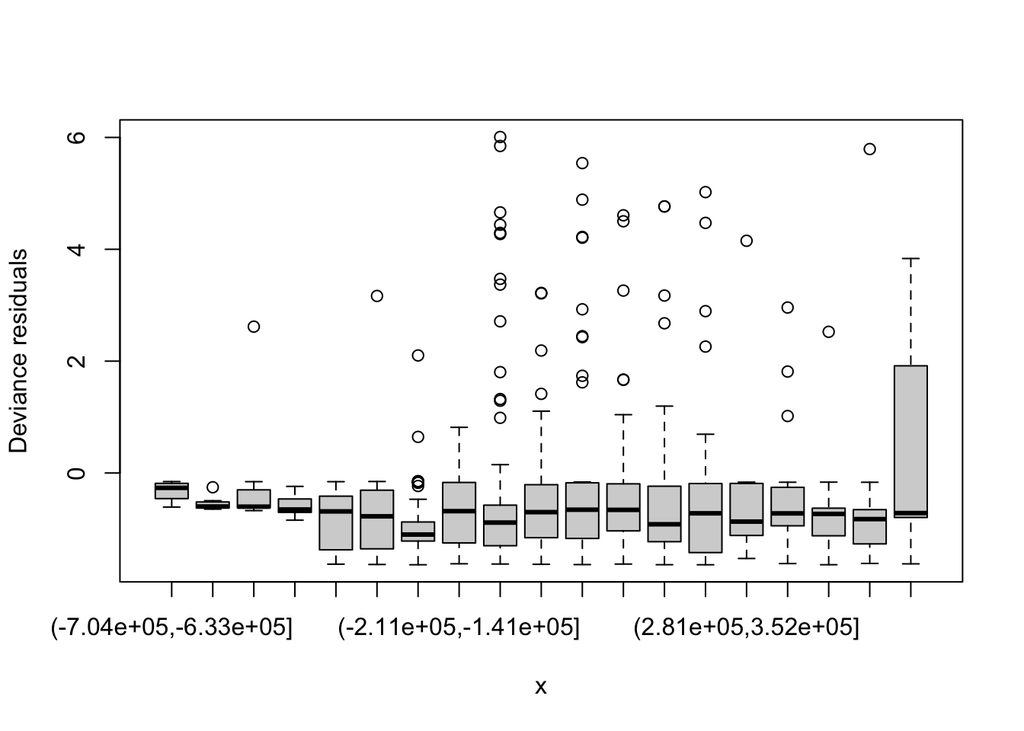

```r
dsm_k_low <- dsm(count ~ s(Depth, k=4),
                    df_hn, segs, obs,
                    family=tw())

# get the data used to fit the model
resid_dat <- dsm_k_low$data

# get the residuals
resid_dat$resids <- residuals(dsm_k_low)

# now let's chop x into 20 chunks
resid_dat$x_chop <- cut(resid_dat$x,
                        seq(min(resid_dat$x), max(resid_dat$x), len=20))

# and plot the boxplot
boxplot(resids~x_chop, data=resid_dat, ylab="Deviance residuals", xlab="x")
```

This seems to show that something is going on in the far east of the data – there’s a wide range of residuals there. Note that for our data the most easterly points are also North (since our data is somewhat diagonal in shape, with respect to the compass). So let’s see if this is an issue with `x` alone (East-West) or `y` (North-Southness) is an issue too.

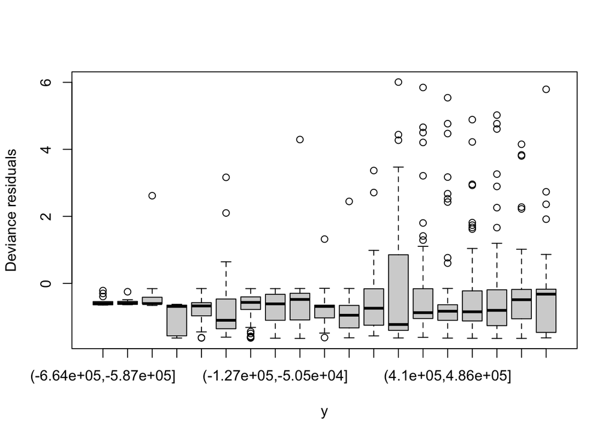

```r
# now let's chop y into 20 chunks
resid_dat$y_chop <- cut(resid_dat$y,
                        seq(min(resid_dat$y), max(resid_dat$y), len=20))

# and plot the boxplot
boxplot(resids~y_chop, data=resid_dat, ylab="Deviance residuals", xlab="y")
```

We can also do this chopping with `Depth` (the only covariate in this model):

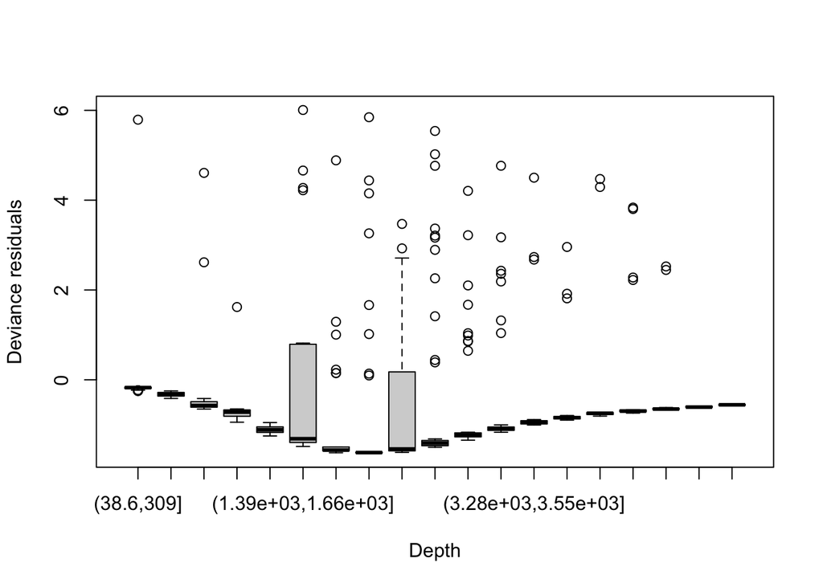

```r
# now let's chop Depth into 20 chunks
resid_dat$Depth_chop <- cut(resid_dat$Depth,
                        seq(min(resid_dat$Depth), max(resid_dat$Depth), len=20))

boxplot(resids~Depth_chop, data=resid_dat, ylab="Deviance residuals", xlab="Depth")
```

Now we see something more pathological, there is pattern in these residuals.

Let’s make the same plot for a model with an spatial smooth in it:

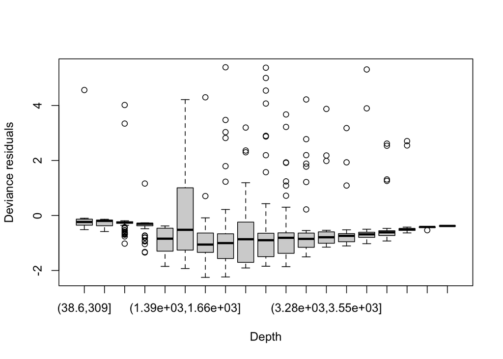

```r
dsm_better <- dsm(count ~ s(x,y) + s(Depth),
                    df_hn, segs, obs,
                    family=tw())

# get the data from the larger k model
resid_dat <- dsm_better$data

# get the residuals
resid_dat$resids <- residuals(dsm_better)

# now let's chop Depth into 20 chunks
resid_dat$Depth_chop <- cut(resid_dat$Depth,
                        seq(min(resid_dat$Depth), max(resid_dat$Depth), len=20))

boxplot(resids~Depth_chop, data=resid_dat, ylab="Deviance residuals", xlab="Depth")
```

This looks better (note the change in vertical axis scale).

Try this out with your models, using the covariates in the model and perhaps `x` and `y` too. You may want to change the number of chunks (via the `len` argument to `cut()`).

**Looking for patterns in the residuals**

Trying this out with the models without smooths of space in them (the habitat models):

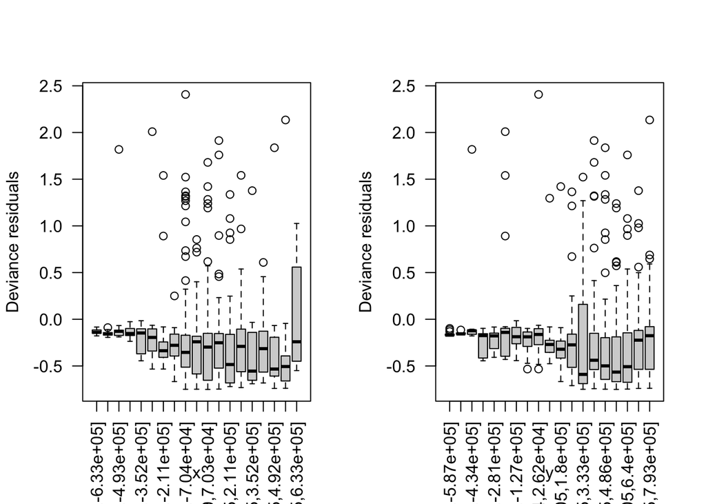

```r
# get the data from the larger k model
resid_dat <- dsm_nb_noxy_ms_p1_3$data

# get the residuals
resid_dat$resids <- residuals(dsm_nb_noxy_ms_p1_3)


# now let's chop x into 20 chunks
resid_dat$x_chop <- cut(resid_dat$x,
                        seq(min(resid_dat$x), max(resid_dat$x), len=20))
# now let's chop y into 20 chunks
resid_dat$y_chop <- cut(resid_dat$y,
                        seq(min(resid_dat$y), max(resid_dat$y), len=20))


par(mfrow=c(1,2))
boxplot(resids~x_chop, data=resid_dat,
        ylab="Deviance residuals", xlab="x", las=2)
boxplot(resids~y_chop, data=resid_dat,
        ylab="Deviance residuals", xlab="y", las=2)
```

Comparing this to the model with space in it:

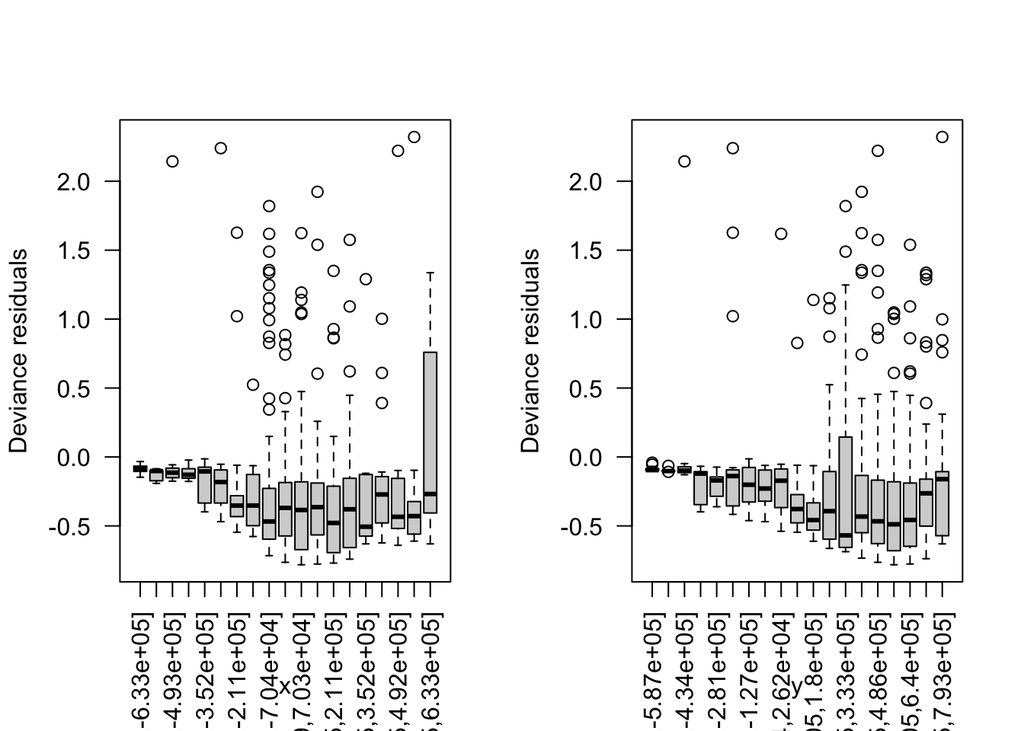

```r
# get the data from the larger k model
resid_dat <- dsm_nb_xy_ms_p1_4$data

# get the residuals
resid_dat$resids <- residuals(dsm_nb_xy_ms_p1_4)


# now let's chop x into 20 chunks
resid_dat$x_chop <- cut(resid_dat$x,
                        seq(min(resid_dat$x), max(resid_dat$x), len=20))
# now let's chop y into 20 chunks
resid_dat$y_chop <- cut(resid_dat$y,
                        seq(min(resid_dat$y), max(resid_dat$y), len=20))


par(mfrow=c(1,2))
boxplot(resids~x_chop, data=resid_dat,
        ylab="Deviance residuals", xlab="x", las=2)
boxplot(resids~y_chop, data=resid_dat,
        ylab="Deviance residuals", xlab="y", las=2)
```

Neither are perfect, there is some pattern in them but we don’t see a really tight pattern as we do in the pathological versions above.

## Fitting models to the residuals

We can also fit a model to the residuals to see if there is residual structure left in the model. The idea here is that we know that the model won’t fit perfectly everywhere, but is the difference between model and data (the residuals) systematic. Going back to our “bad” model above, we can see what happens when things go wrong:

```r
# get the data used to fit the model
resid_dat <- dsm_k_low$data

# get the residuals
resid_dat$resids <- residuals(dsm_k_low)

# fit the model with the same predictors, but larger k
resid_model_depth <- gam(resids ~ s(Depth, k=40),
                         data=resid_dat,
                         family=gaussian(), method="REML")
```

Note that we used the `gam` function from `mgcv` (which is what happens inside `dsm` anyway), to fit our residual model. The important things to note are:

- `gam()` in place of `dsm()`.
- The response is `resids`, the column we added above.
- Theoretically we expect the deviance residuals to be distributed normally, so we set `family=gaussian()`.
- Need to set `method="REML"` which happens automatically in `dsm()`, and makes sure the best method is used for fitting the smooths.

We want to look at the EDFs associated with the terms in the model:

```r
summary(resid_model_depth)
```

```
##
## Family: gaussian
## Link function: identity
##
## Formula:
## resids ~ s(Depth, k = 40)
##
## Parametric coefficients:
##             Estimate Std. Error t value Pr(>|t|)
## (Intercept) -0.54782    0.03492  -15.69   <2e-16 ***
## ---
## Signif. codes:  0 '***' 0.001 '**' 0.01 '*' 0.05 '.' 0.1 ' ' 1
##
## Approximate significance of smooth terms:
##            edf Ref.df     F  p-value
## s(Depth) 3.304   4.14 8.315 1.34e-06 ***
## ---
## Signif. codes:  0 '***' 0.001 '**' 0.01 '*' 0.05 '.' 0.1 ' ' 1
##
## R-sq.(adj) =  0.0344   Deviance explained = 3.77%
## -REML =   1422  Scale est. = 1.1571    n = 949
```

We can see that there’s still a bit of pattern there, but not much (you can also try using `plot()` to investigate this).

Now trying that with the better model:

```r
# get the data used to fit the model
resid_dat_better <- dsm_better$data

# get the residuals
resid_dat_better$resids <- residuals(dsm_better)

# fit the model with the same predictors, but larger k
resid_model_better <- gam(resids ~ s(Depth, bs="ts", k=40) + s(x,y, bs="ts", k=100),
                         data=resid_dat_better,
                         family=gaussian(), method="REML")
```

Now again looking at the EDFs:

```r
summary(resid_model_better)
```

```
##
## Family: gaussian
## Link function: identity
##
## Formula:
## resids ~ s(Depth, bs = "ts", k = 40) + s(x, y, bs = "ts", k = 100)
##
## Parametric coefficients:
##             Estimate Std. Error t value Pr(>|t|)
## (Intercept) -0.45018    0.03071  -14.66   <2e-16 ***
## ---
## Signif. codes:  0 '***' 0.001 '**' 0.01 '*' 0.05 '.' 0.1 ' ' 1
##
## Approximate significance of smooth terms:
##            edf Ref.df     F  p-value
## s(Depth) 2.435     39 0.550 6.79e-06 ***
## s(x,y)   1.028     99 0.045   0.0255 *
## ---
## Signif. codes:  0 '***' 0.001 '**' 0.01 '*' 0.05 '.' 0.1 ' ' 1
##
## R-sq.(adj) =  0.0296   Deviance explained = 3.32%
## -REML = 1302.3  Scale est. = 0.8952    n = 949
```

We see that there’s not much going on in this model. Again you can use `plot()` here, remembering to compare the vertical axis limits and look at the width of the confidence bands.

Try this out with your model(s). What do you think is missing?

**Fitting to the residuals**

Trying this out again with `dsm_nb_noxy_ms_p1_3` (habitat model) and `dsm_nb_xy_ms_p1_4` (model with space included).

I’ll start with the habitat model, where we didn’t include `s(x,y)` from the start. Let’s fit a model to the residuals that includes all of the possible covariates, to see if we’re missing anything…

```r
# make a template data frame from the fitted data
resid_dat_hab <- dsm_nb_noxy_ms_p1_3$data

# get the residuals
resid_dat_hab$resids <- residuals(dsm_nb_noxy_ms_p1_3)

# fit the model with all predictors, but larger k
resid_model_hab <- gam(resids ~ s(x,y, bs="ts", k=60) +
                             s(Depth, bs="ts", k=20) +
                             s(DistToCAS, bs="ts", k=20) +
                             s(SST, bs="ts", k=20) +
                             s(EKE, bs="ts", k=20) +
                             s(NPP, bs="ts", k=20),
                         data=resid_dat_hab,
                         family=gaussian(), method="REML")
summary(resid_model_hab)
```

```
##
## Family: gaussian
## Link function: identity
##
## Formula:
## resids ~ s(x, y, bs = "ts", k = 60) + s(Depth, bs = "ts", k = 20) +
##     s(DistToCAS, bs = "ts", k = 20) + s(SST, bs = "ts", k = 20) +
##     s(EKE, bs = "ts", k = 20) + s(NPP, bs = "ts", k = 20)
##
## Parametric coefficients:
##             Estimate Std. Error t value Pr(>|t|)
## (Intercept) -0.24747    0.01272  -19.46   <2e-16 ***
## ---
## Signif. codes:  0 '***' 0.001 '**' 0.01 '*' 0.05 '.' 0.1 ' ' 1
##
## Approximate significance of smooth terms:
##                    edf Ref.df     F p-value
## s(x,y)       9.335e-01     59 0.089  0.0114 *
## s(Depth)     2.988e+00     19 2.735  <2e-16 ***
## s(DistToCAS) 2.041e-05     19 0.000  0.8395
## s(SST)       2.313e-04     19 0.000  0.6214
## s(EKE)       7.794e-01     19 0.183  0.0332 *
## s(NPP)       4.388e-05     19 0.000  0.7063
## ---
## Signif. codes:  0 '***' 0.001 '**' 0.01 '*' 0.05 '.' 0.1 ' ' 1
##
## R-sq.(adj) =  0.0696   Deviance explained = 7.42%
## -REML = 468.19  Scale est. = 0.15353   n = 949
```

Most of these EDFs are very very small, that’s good! It means we’ve explained most of what’s going on in the data using this model. We can see this a little better by plotting the model terms:

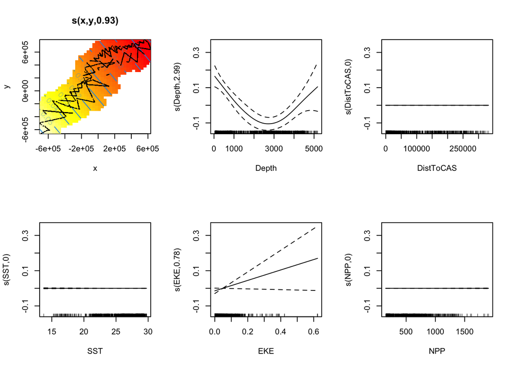

```r
plot(resid_model_hab, scheme=2, pages=1)
```

We can see that the EDF of around 1 for `s(x,y)` here is giving a slight gradient in the spatial smooth of the residuals, but no complex pattern (it’s a plane through the space). Depth might cause use a bit more concern.

Let’s try refitting the model, increasing the `k` for `s(Depth)` and `s(EKE)`:

```r
dsm_nb_noxy_ms_refit <- dsm(count~s(Depth, bs="ts", k=20) +
                             #s(DistToCAS, bs="ts") + # 1
                             #s(SST, bs="ts") + # 2
                             s(EKE, bs="ts", k=20) +
                             s(NPP, bs="ts"),
                      df_hn, segs, obs,
                      family=nb())
summary(dsm_nb_noxy_ms_refit)
```

```
##
## Family: Negative Binomial(0.115)
## Link function: log
##
## Formula:
## count ~ s(Depth, bs = "ts", k = 20) + s(EKE, bs = "ts", k = 20) +
##     s(NPP, bs = "ts") + offset(off.set)
##
## Parametric coefficients:
##             Estimate Std. Error z value Pr(>|z|)
## (Intercept) -20.7750     0.2281  -91.09   <2e-16 ***
## ---
## Signif. codes:  0 '***' 0.001 '**' 0.01 '*' 0.05 '.' 0.1 ' ' 1
##
## Approximate significance of smooth terms:
##             edf Ref.df Chi.sq  p-value
## s(Depth) 3.4649     19 37.088  < 2e-16 ***
## s(EKE)   0.8657     19  5.532   0.0106 *
## s(NPP)   2.8152      9 26.063 1.73e-06 ***
## ---
## Signif. codes:  0 '***' 0.001 '**' 0.01 '*' 0.05 '.' 0.1 ' ' 1
##
## R-sq.(adj) =  0.0966   Deviance explained = 40.7%
## -REML = 383.13  Scale est. = 1         n = 949
```

We don’t see any change here, so it’s not that `k` is the issue. More likely there’s just not enough information in the data to account for the variation that’s there. For example `NPP` is a rough guide to net primary productivity (it’s a measure of epipelagic micronekton, much smaller than the squid we usually see sperm whales eat), so this may not be “close enough” to the prey that sperm whales are interested in.

Trying the same thing for the model that has a smooth of space in it…

```r
# make a template data frame from the fitted data
resid_dat_xy <- dsm_nb_xy_ms_p1_4$data

# get the residuals
resid_dat_xy$resids <- residuals(dsm_nb_xy_ms_p1_4)

# fit the model with the same predictors, but larger k
resid_model_xy <- gam(resids ~ s(x,y, bs="ts", k=60) +
                             s(Depth, bs="ts", k=20) +
                             s(DistToCAS, bs="ts", k=20) +
                             s(SST, bs="ts", k=20) +
                             s(EKE, bs="ts", k=20) +
                             s(NPP, bs="ts", k=20),
                         data=resid_dat_xy,
                         family=gaussian(), method="REML")
summary(resid_model_xy)
```

```
##
## Family: gaussian
## Link function: identity
##
## Formula:
## resids ~ s(x, y, bs = "ts", k = 60) + s(Depth, bs = "ts", k = 20) +
##     s(DistToCAS, bs = "ts", k = 20) + s(SST, bs = "ts", k = 20) +
##     s(EKE, bs = "ts", k = 20) + s(NPP, bs = "ts", k = 20)
##
## Parametric coefficients:
##             Estimate Std. Error t value Pr(>|t|)
## (Intercept) -0.24892    0.01261  -19.74   <2e-16 ***
## ---
## Signif. codes:  0 '***' 0.001 '**' 0.01 '*' 0.05 '.' 0.1 ' ' 1
##
## Approximate significance of smooth terms:
##                    edf Ref.df     F  p-value
## s(x,y)       1.266e+01     59 0.569 9.83e-05 ***
## s(Depth)     2.510e+00     19 2.194  < 2e-16 ***
## s(DistToCAS) 5.518e-01     19 0.064   0.0478 *
## s(SST)       1.349e-04     19 0.000   0.9364
## s(EKE)       6.698e-01     19 0.106   0.0652 .
## s(NPP)       3.077e-04     19 0.000   0.9658
## ---
## Signif. codes:  0 '***' 0.001 '**' 0.01 '*' 0.05 '.' 0.1 ' ' 1
##
## R-sq.(adj) =  0.103   Deviance explained = 11.9%
## -REML = 480.85  Scale est. = 0.15087   n = 949
```

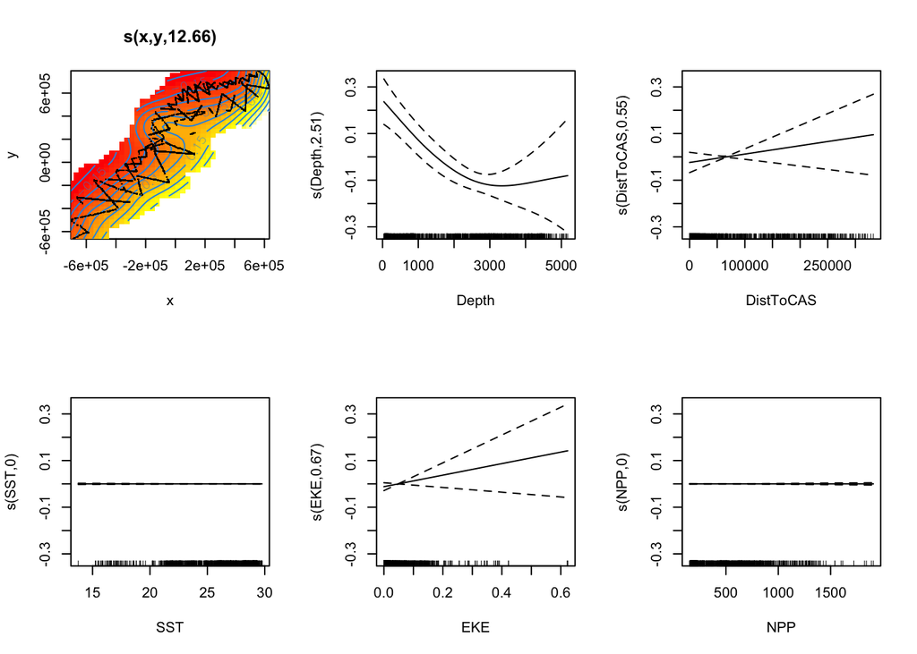

```r
plot(resid_model_xy, scheme=2, pages=1)
```

We see very very similar results to the above. Let’s try refitting that model, but increasing `k` for `s(x,y)`, `s(Depth)` and `s(EKE)`:

```r
dsm_nb_xy_ms_refit <- dsm(count~ #s(x,y, bs="ts", k=60) + # 1
                             s(Depth, bs="ts", k=20) +
                             #s(DistToCAS, bs="ts") + # 2
                             #s(SST, bs="ts") + # 3
                             s(EKE, bs="ts", k=20) +
                             s(NPP, bs="ts"),
                      df_hn, segs, obs,
                      family=nb())
summary(dsm_nb_xy_ms_refit)
```

```
##
## Family: Negative Binomial(0.115)
## Link function: log
##
## Formula:
## count ~ s(Depth, bs = "ts", k = 20) + s(EKE, bs = "ts", k = 20) +
##     s(NPP, bs = "ts") + offset(off.set)
##
## Parametric coefficients:
##             Estimate Std. Error z value Pr(>|z|)
## (Intercept) -20.7750     0.2281  -91.09   <2e-16 ***
## ---
## Signif. codes:  0 '***' 0.001 '**' 0.01 '*' 0.05 '.' 0.1 ' ' 1
##
## Approximate significance of smooth terms:
##             edf Ref.df Chi.sq  p-value
## s(Depth) 3.4649     19 37.088  < 2e-16 ***
## s(EKE)   0.8657     19  5.532   0.0106 *
## s(NPP)   2.8152      9 26.063 1.73e-06 ***
## ---
## Signif. codes:  0 '***' 0.001 '**' 0.01 '*' 0.05 '.' 0.1 ' ' 1
##
## R-sq.(adj) =  0.0966   Deviance explained = 40.7%
## -REML = 383.13  Scale est. = 1         n = 949
```

So! We’ve now ended-up with the same model as `dsm_nb_noxy_ms_refit`!

This again shows that we need to look at multiple outputs, adjust and see what’s going on.

Let’s do the residual plot again for the terms in the model:

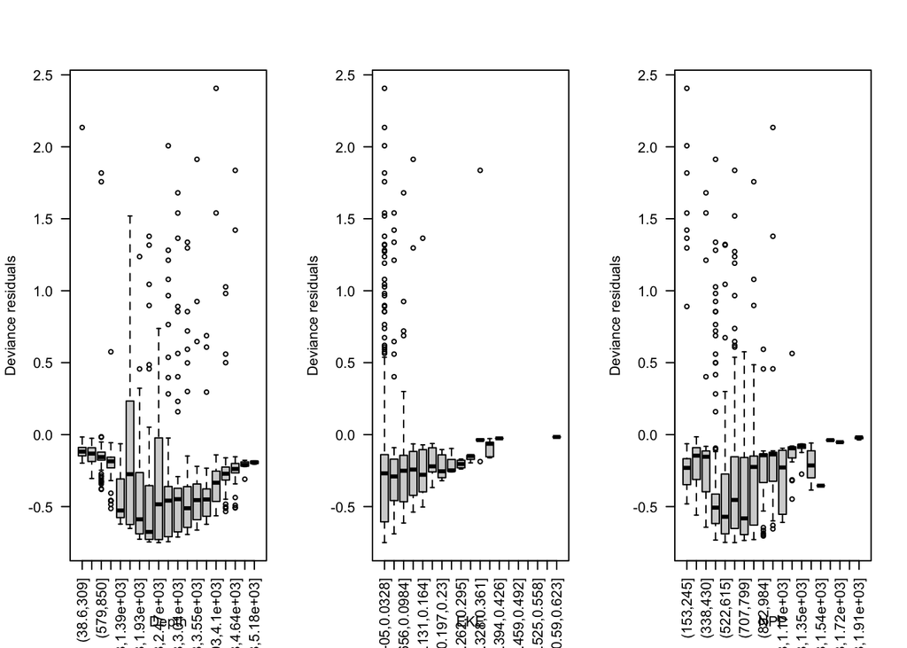

```r
# get the data from the larger k model
resid_dat <- dsm_nb_xy_ms_refit$data

# get the residuals
resid_dat$resids <- residuals(dsm_nb_xy_ms_refit)

# now let's chop Depth into 20 chunks
resid_dat$Depth_chop <- cut(resid_dat$Depth,
                        seq(min(resid_dat$Depth), max(resid_dat$Depth), len=20))

# now let's chop EKE into 20 chunks
resid_dat$EKE_chop <- cut(resid_dat$EKE,
                        seq(min(resid_dat$EKE), max(resid_dat$EKE), len=20))

# now let's chop NPP into 20 chunks
resid_dat$NPP_chop <- cut(resid_dat$NPP,
                        seq(min(resid_dat$NPP), max(resid_dat$NPP), len=20))


par(mfrow=c(1,3))
boxplot(resids~Depth_chop, data=resid_dat,
        ylab="Deviance residuals", xlab="Depth", las=2)
boxplot(resids~EKE_chop, data=resid_dat,
        ylab="Deviance residuals", xlab="EKE", las=2)
boxplot(resids~NPP_chop, data=resid_dat,
        ylab="Deviance residuals", xlab="NPP", las=2)
```

We can see there’s still something going on with `Depth`, but as I said above, this may be down to still not having a good covariate for prey.

Finally we’ll do the same thing with the Tweedie model with space in it `dsm_tw_xy_ms`. First a reminder of what’s in that model:

```r
summary(dsm_tw_xy_ms)
```

```
##
## Family: Tweedie(p=1.279)
## Link function: log
##
## Formula:
## count ~ s(x, y, bs = "ts") + s(Depth, bs = "ts") + s(EKE, bs = "ts") +
##     offset(off.set)
##
## Parametric coefficients:
##             Estimate Std. Error t value Pr(>|t|)
## (Intercept)  -20.673      0.234  -88.33   <2e-16 ***
## ---
## Signif. codes:  0 '***' 0.001 '**' 0.01 '*' 0.05 '.' 0.1 ' ' 1
##
## Approximate significance of smooth terms:
##             edf Ref.df     F  p-value
## s(x,y)   1.8969     29 0.707 1.84e-05 ***
## s(Depth) 3.6949      9 5.024  < 2e-16 ***
## s(EKE)   0.8106      9 0.470   0.0216 *
## ---
## Signif. codes:  0 '***' 0.001 '**' 0.01 '*' 0.05 '.' 0.1 ' ' 1
##
## R-sq.(adj) =  0.105   Deviance explained = 34.9%
## -REML = 385.09  Scale est. = 4.5733    n = 949
```

Now doing the same thing again and refitting to the residuals:

```r
# make a template data frame from the fitted data
resid_dat_xy <- dsm_tw_xy_ms$data

# get the residuals
resid_dat_xy$resids <- residuals(dsm_tw_xy_ms)

# fit the model with all predictors, but larger k
resid_model_xy <- gam(resids ~ s(x,y, bs="ts", k=60) +
                             s(Depth, bs="ts", k=20) +
                             s(DistToCAS, bs="ts", k=20) +
                             s(SST, bs="ts", k=20) +
                             s(EKE, bs="ts", k=20) +
                             s(NPP, bs="ts", k=20),
                         data=resid_dat_xy,
                         family=gaussian(), method="REML")
summary(resid_model_xy)
```

```
##
## Family: gaussian
## Link function: identity
##
## Formula:
## resids ~ s(x, y, bs = "ts", k = 60) + s(Depth, bs = "ts", k = 20) +
##     s(DistToCAS, bs = "ts", k = 20) + s(SST, bs = "ts", k = 20) +
##     s(EKE, bs = "ts", k = 20) + s(NPP, bs = "ts", k = 20)
##
## Parametric coefficients:
##             Estimate Std. Error t value Pr(>|t|)
## (Intercept) -0.49222    0.03223  -15.27   <2e-16 ***
## ---
## Signif. codes:  0 '***' 0.001 '**' 0.01 '*' 0.05 '.' 0.1 ' ' 1
##
## Approximate significance of smooth terms:
##                    edf Ref.df     F  p-value
## s(x,y)       1.076e+01     59 0.440 0.000874 ***
## s(Depth)     1.789e+00     19 0.904 5.42e-06 ***
## s(DistToCAS) 6.035e-01     19 0.078 0.042294 *
## s(SST)       2.494e-04     19 0.000 0.762203
## s(EKE)       9.816e-03     19 0.000 0.304668
## s(NPP)       2.082e-04     19 0.000 0.979887
## ---
## Signif. codes:  0 '***' 0.001 '**' 0.01 '*' 0.05 '.' 0.1 ' ' 1
##
## R-sq.(adj) =  0.0494   Deviance explained = 6.26%
## -REML =   1366  Scale est. = 0.98562   n = 949
```

Again, most of these EDFs are very very small. Let’s again plot the model terms:

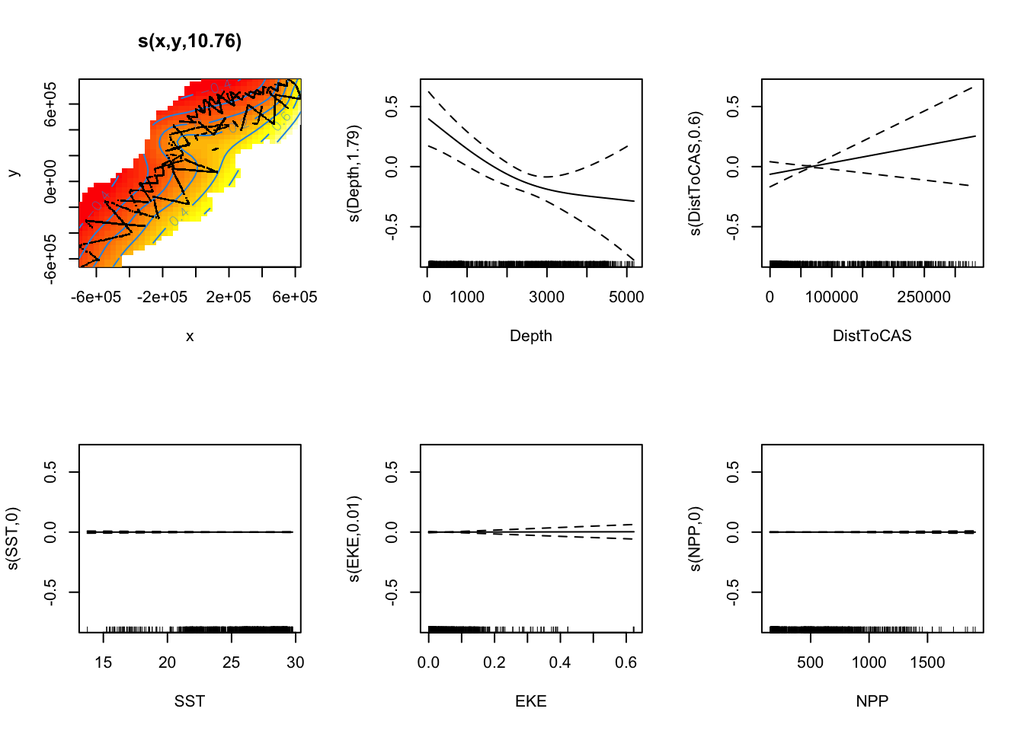

```r
plot(resid_model_xy, scheme=2, pages=1)
```

Looking at the `summary` results and the plot, I think we need to increase `k` for `s(x,y)`, `s(Depth)` and `s(DistToCAS)` (which wasn’t in our model!):

```r
dsm_tw_xy_ms_refit <- dsm(count~s(x,y, bs="ts", k=60)+
                              s(Depth, bs="ts", k=20) +
                             #s(DistToCAS, bs="ts", k=20) + # 1
                             #s(SST, bs="ts") + # 2
                             s(EKE, bs="ts"),# +
                             #s(NPP, bs="ts"),
                      df_hn, segs, obs,
                      family=tw())
summary(dsm_tw_xy_ms_refit)
```

```
##
## Family: Tweedie(p=1.279)
## Link function: log
##
## Formula:
## count ~ s(x, y, bs = "ts", k = 60) + s(Depth, bs = "ts", k = 20) +
##     s(EKE, bs = "ts") + offset(off.set)
##
## Parametric coefficients:
##             Estimate Std. Error t value Pr(>|t|)
## (Intercept)  -20.673      0.234  -88.35   <2e-16 ***
## ---
## Signif. codes:  0 '***' 0.001 '**' 0.01 '*' 0.05 '.' 0.1 ' ' 1
##
## Approximate significance of smooth terms:
##             edf Ref.df     F  p-value
## s(x,y)   1.8967     59 0.348 1.82e-05 ***
## s(Depth) 3.7784     19 2.385  < 2e-16 ***
## s(EKE)   0.8105      9 0.470   0.0216 *
## ---
## Signif. codes:  0 '***' 0.001 '**' 0.01 '*' 0.05 '.' 0.1 ' ' 1
##
## R-sq.(adj) =  0.106   Deviance explained = 34.9%
## -REML = 385.18  Scale est. = 4.572     n = 949
```

So we’re back to where we started! In this case increasing `k` for `DistToCAS` didn’t have any impact on our model selection in the end.

## Using `rqgam.check`

We can use `rqgam.check()` to look at the residual check plots for this model. Here we’re looking for pattern in the plots that would indicate that there is unmodelled structure. Ideally the plot should look like a messy blob of points.

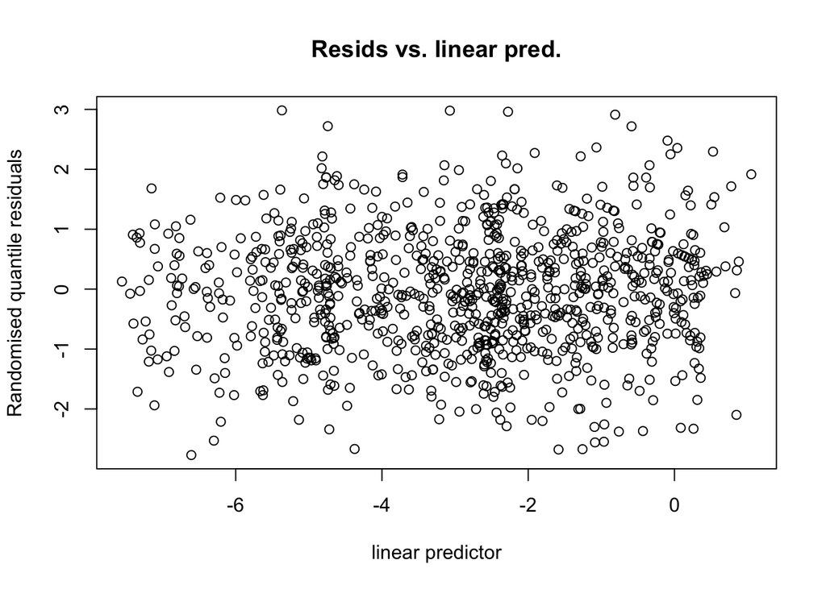

```r
rqgam.check(dsm_better)
```

Try this out with your models and see if there is any pattern in the randomised quantile residuals.

**Checking randomized quantile residuals**

Let’s compare between negative binomial and Tweedie models.

First negative binomial, as refitted above:

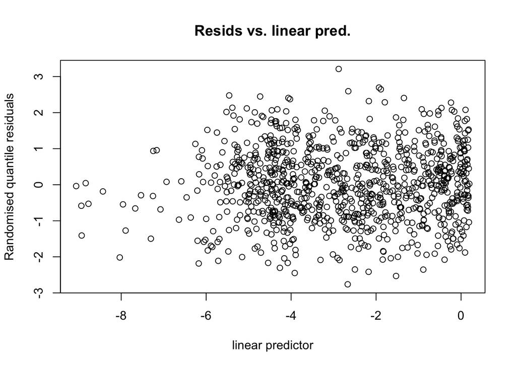

```r
rqgam.check(dsm_nb_noxy_ms_refit)
```

Then Tweedie:

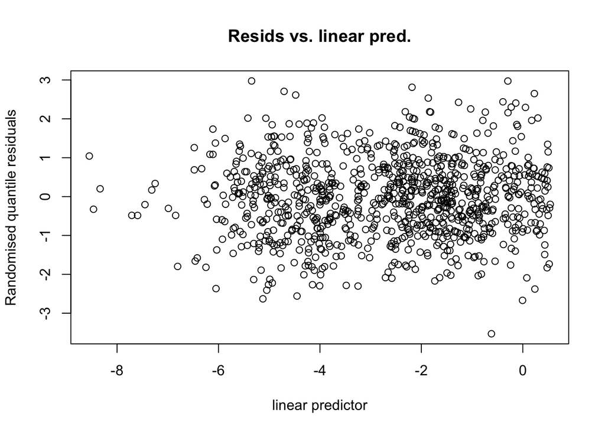

```r
rqgam.check(dsm_tw_xy_ms)
```

Both of these seem fine, not pathological like those in the lecture slides.

## Using `obs_exp`

To compare the observed vs. expected counts from the model, we need to aggregate the data at some level. We can use `obs_exp()` to do this. For continuous covariates in the detection function or spatial moel, we just need to specify the cutpoints. For example:

```r
obs_exp(dsm_better, "Depth", c(0, 1000, 2000, 3000, 4000, 6000))
```

```
##          (0,1e+03] (1e+03,2e+03] (2e+03,3e+03] (3e+03,4e+03] (4e+03,6e+03]
## Observed  4.000000      52.53333      139.1667      35.00000      8.000000
## Expected  5.163824      49.92310      126.8073      38.65673      8.134937
```

Try this out for your models.

**Looking at observed vs. expected counts**

Again trying this for our negative binomial habitat model using the `Depth` covariate:

```r
obs_exp(dsm_nb_noxy_ms_refit, "Depth", c(0, 1000, 2000, 3000, 4000, 6000))
```

```
##          (0,1e+03] (1e+03,2e+03] (2e+03,3e+03] (3e+03,4e+03] (4e+03,6e+03]
## Observed  4.000000      52.53333      139.1667      35.00000      8.000000
## Expected  4.973135      39.26691      122.2847      51.45393      7.425874
```

This looks pretty good! We can try with `EKE` and `NPP` too:

```r
# for EKE the majority of the values are between 0 and
# 0.05, so we'll put more bins there and make bins larger for larger values -- see hist(segs$EKE)
obs_exp(dsm_nb_noxy_ms_refit, "EKE", c(0, 0.01, 0.025, 0.05, 0.1, 0.4, 0.7))
```

```
##          (0,0.01] (0.01,0.025] (0.025,0.05] (0.05,0.1] (0.1,0.4]  (0.4,0.7]
## Observed 161.9500      37.7500     17.00000   15.00000  7.000000 0.00000000
## Expected 134.0855      42.0134     22.50145   18.88298  7.920128 0.00107712
```

```r
# we can get the default breaks we have from hist()
npp_breaks <- hist(segs$NPP, plot=FALSE)$breaks
obs_exp(dsm_nb_noxy_ms_refit, "NPP", npp_breaks)
```

```
##            (0,200] (200,400] (400,600] (600,800] (800,1e+03] (1e+03,1.2e+03]
## Observed 11.450000   7.50000  98.38333  81.36667    28.00000       11.000000
## Expected  9.531847  13.22469  82.90801  88.24576    24.38344        6.143246
##          (1.2e+03,1.4e+03] (1.4e+03,1.6e+03] (1.6e+03,1.8e+03] (1.8e+03,2e+03]
## Observed         1.0000000         0.0000000       0.000000000     0.000000000
## Expected         0.6519371         0.3115906       0.002891405     0.001170438
```

Again, these seem pretty reasonable!

Doing the same thing for the Tweedie model `dsm_tw_xy_ms`, again using the default histogram breaks for `x` and `y`:

```r
x_breaks <- hist(segs$x, plot=FALSE)$breaks
obs_exp(dsm_tw_xy_ms, "x", x_breaks)
```

```
##          (-8e+05,-7e+05] (-7e+05,-6e+05] (-6e+05,-5e+05] (-5e+05,-4e+05]
## Observed      0.00000000       0.0000000        1.000000       0.0000000
## Expected      0.00316796       0.3395217        0.561756       0.8881759
##          (-4e+05,-3e+05] (-3e+05,-2e+05] (-2e+05,-1e+05] (-1e+05,0] (0,1e+05]
## Observed         0.00000        7.450000        43.33333   50.91667  54.00000
## Expected         3.27297        8.245829        25.72470   43.54315  49.57802
##          (1e+05,2e+05] (2e+05,3e+05] (3e+05,4e+05] (4e+05,5e+05] (5e+05,6e+05]
## Observed      34.00000      21.00000       13.0000      1.000000      4.000000
## Expected      48.27922      22.73238       11.3278      9.773835      7.411754
##          (6e+05,7e+05]
## Observed      9.000000
## Expected      1.645921
```

```r
y_breaks <- hist(segs$y, plot=FALSE)$breaks
obs_exp(dsm_tw_xy_ms, "y", y_breaks)
```

```
##          (-7e+05,-6e+05] (-6e+05,-5e+05] (-5e+05,-4e+05] (-4e+05,-3e+05]
## Observed      0.00000000      0.00000000       1.0000000          0.0000
## Expected      0.06294614      0.05824977       0.2168808          2.8786
##          (-3e+05,-2e+05] (-2e+05,-1e+05] (-1e+05,0] (0,1e+05] (1e+05,2e+05]
## Observed        7.450000        0.000000   0.000000  4.000000       2.00000
## Expected        2.376874        3.428002   3.866229  8.603532      11.44869
##          (2e+05,3e+05] (3e+05,4e+05] (4e+05,5e+05] (5e+05,6e+05] (6e+05,7e+05]
## Observed      41.33333      52.91667      29.00000      57.00000      37.00000
## Expected      20.73613      19.88760      41.55495      58.52634      51.50198
##          (7e+05,8e+05]
## Observed      7.000000
## Expected      8.181202
```

```r
obs_exp(dsm_tw_xy_ms, "Depth", c(0, 1000, 2000, 3000, 4000, 6000))
```

```
##          (0,1e+03] (1e+03,2e+03] (2e+03,3e+03] (3e+03,4e+03] (4e+03,6e+03]
## Observed   4.00000      52.53333      139.1667      35.00000      8.000000
## Expected   5.80883      47.76153      131.9859      39.23381      8.538091
```

```r
# again need to be careful with EKE
obs_exp(dsm_tw_xy_ms, "EKE", c(0, 0.01, 0.025, 0.05, 0.1, 0.4, 0.7))
```

```
##          (0,0.01] (0.01,0.025] (0.025,0.05] (0.05,0.1] (0.1,0.4]   (0.4,0.7]
## Observed 161.9500     37.75000     17.00000   15.00000  7.000000 0.000000000
## Expected 151.2765     34.55754     19.68545   18.86281  8.944266 0.001596079
```

The `EKE` and `Depth` results look good, but the spatial terms look less good. That’s just because we’re taking marginals of a 2 dimensional distribution. We might do better looking at “areas of interest” or other covariates here. For example we can look at `DistToCAS` even though it’s not in the model:

```r
# again need to inspect hist(segs$DistToCAS) first
obs_exp(dsm_tw_xy_ms, "DistToCAS", c(-1e-10, 1000, 2000, 5000, 10000, 350000))
```

```
##          (-1e-10,1e+03] (1e+03,2e+03] (2e+03,5e+03] (5e+03,1e+04]
## Observed       44.05000      43.83333      28.50000       24.2000
## Expected       38.94865      31.87421      29.49987       31.5549
##          (1e+04,3.5e+05]
## Observed        98.11667
## Expected       101.45057
```

This looks pretty good!

## Saving models

Now save the models that you’d like to use to predict with later (that have good check results!): I recommend saving a few models so you can compare the results later.

```r
# add your models here
save(dsm_nb_noxy_ms_refit, dsm_tw_xy_ms,
     file="dsms-checked.RData")
```